# Go Help Yourself?

- Show All Code
- Hide All Code
- View Source

Teacher Educator Attributions of Failure and the Provision of Social Support

Author

Affiliation

David Simon

DIPF | Leibniz Institute for Research and Information in Education

Published

11 December 2024

## Information

```r
# Input: b_sab_mzp2_2024_R_data_file.csv
#
# Output: --
#
# Contents: (1) Read Data
#           (2) Measures
#           (3) Results

####  ------------- Load Packages ------------- ####
library(here)           # find files
library(tidyverse)      # for data management
library(psych)          # for scale construction, EFA, CFA
library(lavaan)         # for SEM
```

## Data Analysis

### 1 Read Data

Data:

```r
data <- read.csv(here("01_data/b_sab_mzp2_2024_R_data_file.csv"))
```

### 2 Measures

#### 2.1 Exploratory Factor Analysis (EFA): Social Support Scales

The items measuring social support were taken from Richter at al. (2011) and Schulz and Schwarzer (2003). We adapted to the educators’ perspective. Items were added to each facet according to our theoretical understanding of social support. An EFA was calculated to determine which items represented the three facets of social support best.

##### Dataevaluation

Data for EFA:

```r
data_efa <- data %>%
  dplyr::select(sozunt_ins5:sozunt_ins2)
```

*Kaiser–Meyer–Olkin (KMO) Test:*

- 0.00 - 0.49: Unacceptable
- 0.50 - 0.59: Miserable
- 0.60 - 0.69: Mediocre
- 0.70 - 0.79: Middling
- 0.80 - 0.89: Meritorious
- 0.90 - 1.00: Marvelous

```r
psych::KMO(data_efa)
```

```
Kaiser-Meyer-Olkin factor adequacy
Call: psych::KMO(r = data_efa)
Overall MSA =  0.73
MSA for each item =
sozunt_ins5 sozunt_ins1 sozunt_ins4 sozunt_emo5 sozunt_inf3 sozunt_emo1
       0.54        0.63        0.46        0.79        0.80        0.76
sozunt_inf1 sozunt_emo2 sozunt_inf2 sozunt_emo3 sozunt_ins3 sozunt_emo4
       0.66        0.75        0.74        0.84        0.56        0.74
sozunt_inf4 sozunt_inf5 sozunt_ins2
       0.75        0.71        0.65
```

Deletion of item `sozunt_ins4`, who failed the KMO test (< 0.50):

```r
data_efa <- data_efa %>%
  dplyr::select(-sozunt_ins4)
```

*Bartlett Test of Sphericity:*

```r
psych::cortest.bartlett(data_efa)$p.value
```

```
[1] 2.741673e-103
```

##### Exploratory Factor Analysis

*Step 1: Plausibility of a three factor solution*

Get Eigenvalues:

```r
eig <- eigen(cor(data_efa, use = "complete.obs")) # get eigenvalues
eig$values
```

```
 [1] 4.0036774 1.6535833 1.1527839 1.0245965 0.9837237 0.9307922 0.8425965
 [8] 0.6567110 0.6496322 0.5762360 0.5100431 0.4243738 0.3284660 0.2627844
```

Show scree plot:

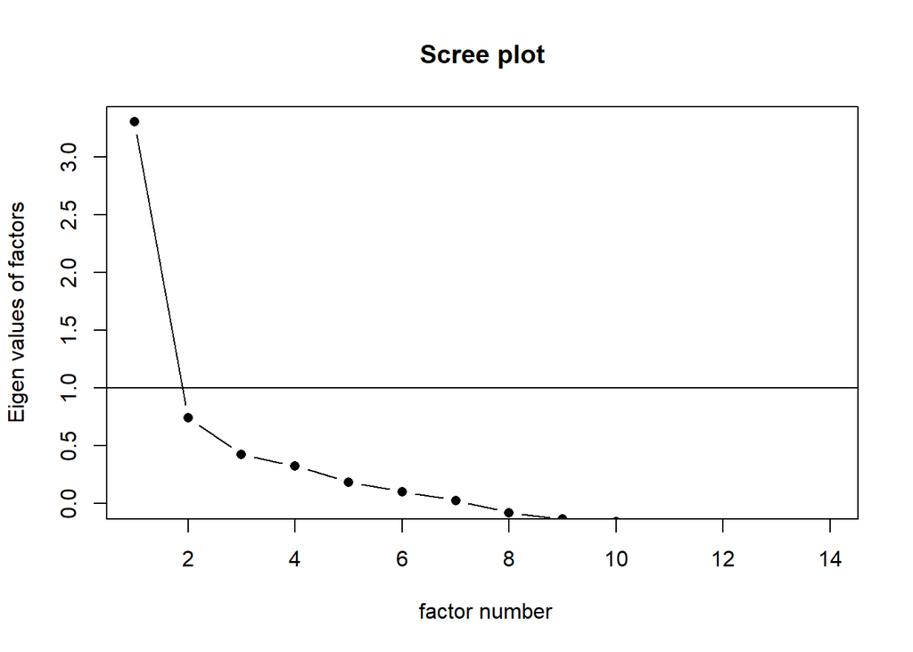

```r
psych::scree(data_efa, pc = FALSE)  # plot scree plot
```

The eigenvalue method (“Kaiser’s rule”) suggested four factors. The scree plot suggested two factors. In line with our theoretical understanding of the construct we started with three factors first, assuming correlated factors:

*Step 2: Factor extraction*

```r
efa <- psych::fa(data_efa, nfactors = 3, rotate = "oblimin")
loadings <- efa$loadings
loadings
```

```
Loadings:
            MR1    MR3    MR2
sozunt_ins5 -0.200         0.536
sozunt_ins1                0.728
sozunt_emo5  0.329  0.349
sozunt_inf3  0.720         0.163
sozunt_emo1  0.226         0.289
sozunt_inf1  0.454
sozunt_emo2  0.347  0.337
sozunt_inf2  0.538
sozunt_emo3  0.335  0.413
sozunt_ins3  0.148         0.259
sozunt_emo4         0.927
sozunt_inf4  0.597  0.123
sozunt_inf5  0.684        -0.136
sozunt_ins2         0.104  0.248

                 MR1   MR3   MR2
SS loadings    2.304 1.312 1.101
Proportion Var 0.165 0.094 0.079
Cumulative Var 0.165 0.258 0.337
```

*Step 3: Item removal*

Only variables with loadings of .32 and above were interpreted as suggested as a first rule of thumb by Tabachnick and Fidell (2001).

Consequently `sozunt_emo1`, `sozunt_ins3` and `sozunt_ins2` were not further considered:

```r
data_efa <- data_efa %>%
  dplyr::select(-sozunt_emo1, -sozunt_ins3, -sozunt_ins2)
```

The EFA was repeated:

```r
efa <- psych::fa(data_efa, nfactors = 3, rotate = "oblimin")
loadings <- efa$loadings
loadings
```

```
Loadings:
            MR1    MR3    MR2
sozunt_ins5 -0.145         0.598
sozunt_ins1  0.199         0.652
sozunt_emo5  0.263  0.411
sozunt_inf3  0.815         0.132
sozunt_inf1  0.388
sozunt_emo2  0.172  0.493 -0.150
sozunt_inf2  0.477  0.152
sozunt_emo3  0.195  0.534
sozunt_emo4         0.841
sozunt_inf4  0.562  0.176
sozunt_inf5  0.582  0.114 -0.217

                 MR1   MR3   MR2
SS loadings    1.900 1.482 0.884
Proportion Var 0.173 0.135 0.080
Cumulative Var 0.173 0.307 0.388
```

*Step 4: Interpretation of factors*

Factors were interpreted given the intended theoretical assignment of items to factors and a final cut of .45 regarding the loadings, which equals a 20% variance overlap between variable and factor and was characterised as “fair” by Comray (-Comrey (1962)) and examplified in Tabachnick and Fidell (2001).

This resulted in the following three factors, which correspond to the three facets of social support:

- Factor 1: Informational support (“Tips and advice”) was best represented through the items `sozunt_inf2`, `sozunt_inf3`, `sozunt_inf4` and `sozunt_inf5`,
- Factor 2: Emotional support (“Comfort and nearness”) was best represented through the items `sozunt_emo2`, `sozunt_emo3` and `sozunt_emo4`.
- Factor 3: Instrumental support (“Goods and materials”) was best represented through the items `sozunt_ins1` and `sozunt_ins5`,

Adjustment of data accordingly:

```r
data_efa <- data_efa %>%
  dplyr::select(sozunt_inf2, sozunt_inf3, sozunt_inf4, sozunt_inf5,
                sozunt_emo2, sozunt_emo3, sozunt_emo4,
                sozunt_ins1, sozunt_ins5)
```

*Step 5: Final solution*

```r
efa <- psych::fa(data_efa, nfactors = 3, rotate = "oblimin")
loadings <- efa$loadings
loadings
```

```
Loadings:
            MR1    MR3    MR2
sozunt_inf2  0.420  0.247
sozunt_inf3  0.802         0.130
sozunt_inf4  0.547  0.178
sozunt_inf5  0.594  0.127 -0.219
sozunt_emo2         0.529 -0.135
sozunt_emo3  0.138  0.597
sozunt_emo4         0.786
sozunt_ins1  0.218         0.646
sozunt_ins5 -0.167         0.612

                 MR1   MR3   MR2
SS loadings    1.576 1.374 0.891
Proportion Var 0.175 0.153 0.099
Cumulative Var 0.175 0.328 0.427
```

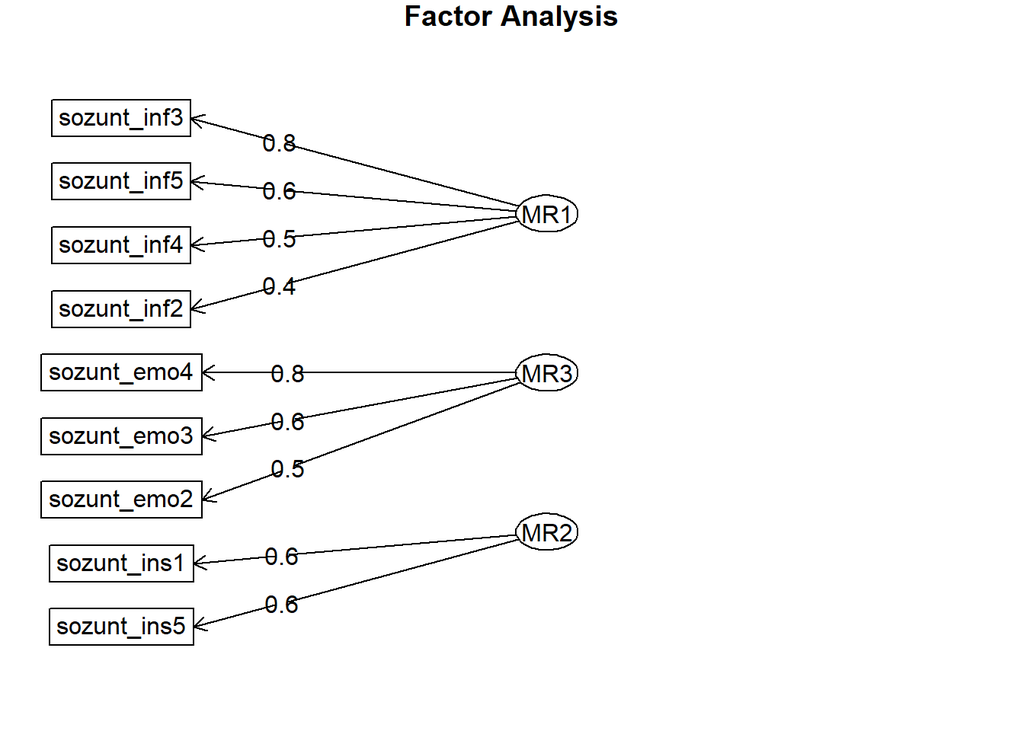

```r
psych::fa.diagram(loadings)
```

*Step 6: Evaluate Reliability*

```r
inf_sup_alpha <- data %>%
  dplyr::select(sozunt_inf2, sozunt_inf3, sozunt_inf4, sozunt_inf5) %>%
  psych::alpha(title = "sozunt_inf")

emo_sup_alpha <- data %>%
  dplyr::select(sozunt_emo2, sozunt_emo3, sozunt_emo4) %>%
  psych::alpha(title = "sozunt_emo")

ins_sup_alpha <- data %>%
  dplyr::select(sozunt_ins1, sozunt_ins5) %>%
  psych::alpha(title = "sozunt_ins")
```

- Alpha informational support: 0.7495715
- Alpha emotional support: 0.6952986
- Alpha instrumental support: 0.5591961

*Step 7: Does this solution fit the data?*

```r
three_efa_ml <- psych::fa(data_efa, nfactors = 3, rotate = "oblimin", fm = "ml")

three_efa_ml_chisq <- three_efa_ml$STATISTIC  # chi-square statistic
three_efa_ml_pval <- three_efa_ml$PVAL  # p-value
```

- Chi-square: 40.2897647
- P-value: 6.4363233^{-5}

And further parsimoniousness would not:

```r
two_efa_ml <- fa(data_efa, nfactors = 2, rotate = "oblimin", fm = "ml")

two_efa_ml_chisq <- two_efa_ml$STATISTIC  # chi-square statistic
two_efa_ml_pval <- two_efa_ml$PVAL  # p-value
```

- Chi-square: 88.2168063
- P-value: 6.8553596^{-11}

#### 2.2 Confirmatory Factor Analysis (CFA): Self-Efficacy Scale

Tickell and Klassen (2024) developed a scale for measuring teacher mentoring self-efficacy beliefs and suggest a two-factor model, with factors named as *Pedagogical Practices* and *Professional Relationships*. We tested this factor structure in our German translation of the questionnaire:

##### Confirmatory Factor Analysis

Data for CFA:

```r
data_cfa <- data %>%
  dplyr::select(seffsab_1:seffsab_9)
```

*Step 1: Fitting a two-factor model*

```r
# specify the model
cfa_model <- ' pae =~ seffsab_1 + seffsab_2 + seffsab_20 + seffsab_14 +
                      seffsab_6 + seffsab_28 + seffsab_48 + seffsab_39 +
                      seffsab_46 + seffsab_47 + seffsab_4
               rel =~ seffsab_29 + seffsab_44 + seffsab_27 + seffsab_42 +
                      seffsab_9 '

# fit the model
fit_cfa <- cfa(cfa_model, data = data_cfa)
```

Model fit was poor:

```r
# CFI cut-off: .95; SRMR cut-off: .09
fitMeasures(fit_cfa, c("chisq", "df", "pvalue", "cfi", "srmr"))
```

```
  chisq      df  pvalue     cfi    srmr
215.362 103.000   0.000   0.793   0.080
```

*Step 2: Evaluate Reliability*

In order to improve the model-fit we evaluated reliability:

```r
sef_pea_alpha <- data %>%
  dplyr::select(seffsab_1, seffsab_2, seffsab_20, seffsab_14, seffsab_6,
                seffsab_28, seffsab_48, seffsab_39, seffsab_46, seffsab_47,
                seffsab_4) %>%
  psych::alpha(title = "sef_pea_alpha")

sef_rel_alpha <- data %>%
  dplyr::select(seffsab_29, seffsab_44, seffsab_27, seffsab_42, seffsab_9) %>%
  psych::alpha(title = "sef_rel_alpha")
```

```r
sef_pea_alpha$alpha.drop
```

```
           raw_alpha std.alpha   G6(smc) average_r      S/N   alpha se
seffsab_1  0.7675752 0.7825107 0.7930615 0.2645939 3.597928 0.02358648
seffsab_2  0.7726284 0.7900613 0.7998655 0.2734298 3.763296 0.02297911
seffsab_20 0.7736523 0.7917881 0.8019784 0.2755093 3.802800 0.02306662
seffsab_14 0.7673604 0.7877438 0.8030774 0.2706739 3.711287 0.02370081
seffsab_6  0.7553413 0.7742482 0.7840826 0.2553786 3.429643 0.02475996
seffsab_28 0.7777442 0.7977995 0.8087002 0.2829272 3.945586 0.02258525
seffsab_48 0.7953469 0.8013891 0.8039725 0.2874940 4.034970 0.02058919
seffsab_39 0.7607308 0.7843228 0.7916116 0.2666771 3.636558 0.02433846
seffsab_46 0.7619324 0.7829225 0.7965882 0.2650653 3.606650 0.02417368
seffsab_47 0.7789207 0.7963034 0.8040723 0.2810546 3.909263 0.02228678
seffsab_4  0.7647377 0.7834701 0.7958490 0.2656940 3.618300 0.02380364
                 var.r     med.r
seffsab_1  0.011088651 0.2640925
seffsab_2  0.010656359 0.2748633
seffsab_20 0.010602860 0.2748633
seffsab_14 0.012785886 0.2670734
seffsab_6  0.010192410 0.2639653
seffsab_28 0.010659817 0.2763067
seffsab_48 0.007299239 0.2803319
seffsab_39 0.010880640 0.2640925
seffsab_46 0.012374455 0.2639653
seffsab_47 0.009507307 0.2763067
seffsab_4  0.011015944 0.2670734
```

```r
sef_rel_alpha$alpha.drop
```

```
           raw_alpha std.alpha   G6(smc) average_r      S/N   alpha se
seffsab_29 0.7383249 0.7456555 0.6950650 0.4229389 2.931675 0.02825582
seffsab_44 0.6412061 0.6688488 0.6108337 0.3355226 2.019768 0.03841712
seffsab_27 0.6867792 0.7242452 0.6799264 0.3963549 2.626410 0.03427095
seffsab_42 0.6915352 0.7191365 0.6723265 0.3902855 2.560448 0.03250161
seffsab_9  0.7023552 0.7251581 0.6752984 0.3974502 2.638455 0.03272440
                 var.r     med.r
seffsab_29 0.005626831 0.4179740
seffsab_44 0.004111728 0.3457231
seffsab_27 0.012124621 0.4203259
seffsab_42 0.008219606 0.4077643
seffsab_9  0.006017917 0.4077643
```

```r
data_cfa <- data_cfa %>%
  dplyr::select(-seffsab_48)

# specify the model
cfa_model_2 <- ' pae =~ seffsab_1 + seffsab_2 + seffsab_20 + seffsab_14 +
                        seffsab_6 + seffsab_28 + seffsab_39 + seffsab_46 +
                        seffsab_47 + seffsab_4
                 rel =~ seffsab_29 + seffsab_44 + seffsab_27 + seffsab_42 +
                        seffsab_9 '

# fit the model
fit_cfa_2 <- cfa(cfa_model_2, data = data_cfa)
fitMeasures(fit_cfa_2, c("chisq", "df", "pvalue", "cfi", "srmr"))
```

```
  chisq      df  pvalue     cfi    srmr
173.665  89.000   0.000   0.834   0.073
```

Model fit improved, but was still not good enough;

```r
# CFI cut-off: .95; SRMR cut-off: .09
fitMeasures(fit_cfa_2, c("chisq", "df", "pvalue", "cfi", "srmr"))
```

```
  chisq      df  pvalue     cfi    srmr
173.665  89.000   0.000   0.834   0.073
```

Looking at the reliability output again, we saw no room for further improvement:

```r
sef_pea_alpha <- data %>%
  dplyr::select(seffsab_1, seffsab_2, seffsab_20, seffsab_14, seffsab_6,
                seffsab_28, seffsab_39, seffsab_46, seffsab_47, seffsab_4) %>%
  psych::alpha(title = "sef_pea_alpha")

sef_pea_alpha$alpha.drop
```

```
           raw_alpha std.alpha   G6(smc) average_r      S/N   alpha se
seffsab_1  0.7753606 0.7784735 0.7755952 0.2808131 3.514132 0.02272659
seffsab_2  0.7801776 0.7854234 0.7825412 0.2891186 3.660340 0.02214275
seffsab_20 0.7842585 0.7904511 0.7865887 0.2953422 3.772157 0.02191970
seffsab_14 0.7798508 0.7854127 0.7884445 0.2891055 3.660107 0.02235078
seffsab_6  0.7622493 0.7690438 0.7657186 0.2700626 3.329825 0.02403292
seffsab_28 0.7867444 0.7947399 0.7933076 0.3008008 3.871868 0.02161895
seffsab_39 0.7812089 0.7878398 0.7879259 0.2920867 3.713420 0.02210432
seffsab_46 0.7728446 0.7805547 0.7805981 0.2832651 3.556944 0.02296684
seffsab_47 0.7826076 0.7897432 0.7887248 0.2944546 3.756089 0.02201891
seffsab_4  0.7702703 0.7776843 0.7778353 0.2798910 3.498108 0.02324943
                 var.r     med.r
seffsab_1  0.007052230 0.2783193
seffsab_2  0.006858994 0.2846692
seffsab_20 0.005818442 0.2846692
seffsab_14 0.008822877 0.2905708
seffsab_6  0.006206610 0.2704768
seffsab_28 0.006527291 0.3005517
seffsab_39 0.008059722 0.2964722
seffsab_46 0.008491830 0.2775231
seffsab_47 0.007356747 0.2905708
seffsab_4  0.007456054 0.2775231
```

Although the model fit was not as good as desired, we considered it to be sufficient.

#### 2.3 Compute Scale Scores

```r
# Factor vignette, dummy for each vignette
data <- data %>%
  dplyr::mutate(vig = case_when((random == 1) ~ 1,
                                (random == 2) ~ 2,
                                (random == 3) ~ 3,
                                TRUE ~ as.numeric(NA)),
                vig1 = ifelse(vig == 1, 1, 0),
                vig2 = ifelse(vig == 2, 1, 0),
                vig3 = ifelse(vig == 3, 1, 0))


data$vig <- as.factor(data$vig)

## Attribution

data <- data %>%
  dplyr::mutate(int = int_1,  # internality
                sta = sta_1,  # stability
                glo = glo_1,  # globality
                con = kon_1)  # controllability

# Attribution style: Int, Sta, Glo
data <- data %>%
  dplyr::mutate(isg = rowMeans(subset(data, select = c(int, sta, glo)), na.rm = TRUE))

isg_alpha <- data %>%
  dplyr::select(int, sta, glo) %>%
  psych::alpha(title = "isg_alpha")


## Affect

# Negative affect, positive affect
data <- data %>%
  dplyr::mutate(pos_aff = rowMeans(subset(data, select = c(affekt_1, affekt_3,
                                                           affekt_4, affekt_6,
                                                           affekt_10, affekt_11,
                                                           affekt_12, affekt_15)),
                                   na.rm = TRUE),
                neg_aff = rowMeans(subset(data, select = c(affekt_2, affekt_5,
                                                           affekt_7, affekt_8,
                                                           affekt_13, affekt_14,
                                                           affekt_16)),
                                   na.rm = TRUE),
                ang = affekt_5,   # Anger
                gui = affekt_7,   # Guilt
                sha = affekt_14)  # Shame


## Social Support

# Informational support: "Hinweise und Ratschläge"
data <- data %>%
  dplyr::mutate(inf_sup = rowMeans(subset(data, select = c(sozunt_inf2,
                                                           sozunt_inf3,
                                                           sozunt_inf4,
                                                           sozunt_inf5)),
                                   na.rm = TRUE),

# Emotional support: "Trost und Nähe"
                emo_sup = rowMeans(subset(data, select = c(sozunt_emo2,
                                                           sozunt_emo3,
                                                           sozunt_emo4)),
                                   na.rm = TRUE),

## Instrumental support: "Güter und Materialien"
                ins_sup = rowMeans(subset(data, select = c(sozunt_ins1,
                                                           sozunt_ins5)),
                                 na.rm = TRUE))

## Self Efficacy

# Self Efficacy, Factor 1: Pedagogical Practices
data <- data %>%
  dplyr::mutate(seff_f1 = rowMeans(subset(data, select = c(seffsab_1, seffsab_2,
                                                           seffsab_20, seffsab_14,
                                                           seffsab_6, seffsab_28,
                                                           seffsab_39, seffsab_46,
                                                           seffsab_47, seffsab_4)),
                                   na.rm = TRUE),

# Self Efficacy, Factor 2: Relationships
                seff_f2 = rowMeans(subset(data, select = c(seffsab_29,seffsab_44,
                                                           seffsab_27,seffsab_42,
                                                           seffsab_9)),
                                   na.rm = TRUE))
```

#### 2.4 Glossary

*Attributions*  
adapted from (Steinsmeier et al., 1985)

- `int`: Internality
- `sta`: Stability
- `glo`: Globality
- `con`: Controllability

*Affect*  
after (Breyer & Bluemke, 2016)

- `pos_aff`: Positive Affect
- `neg_aff`: Negative Affect
- `ang`: Anger
- `gui`: Guilt
- `sha`: Shame

*Social Support*  
adapted from (Richter et al., 2011)

- `inf_sup`: Informational support
- `ins_sup`: Instrumental support
- `emo_sup`: Emotional Support

*Self Efficacy*  
adapted from (Tickell & Klassen, 2024)

- `seff_f1`: Pedagogical Practices
- `seff_f2`: Relationships

### 3 Results

#### 3.1 Attributional Theory

Weiner (1985) identified three causal dimensions.

One dimension of causes is their *locus*, or location within or outside of the actor (locus of control). Ability and effort are similar in locus, both being internal to the actor. In addition, they differ from causes such as chance or task difficulty, which are considered to be located in the environment, external to the actor.

A second dimension of causes is *stability*, which depicts a cause as constant or changing over time. Some causes, including ability, are viewed as stable over time. On the other hand, chance or luck fluctuates over time and is therefore unstable. Effort also is typically regarded as unstable, although labeling oneself or others as lazy or industrious implies stability in effort expenditure.

The third known causal dimension is *controllability*, or whether a cause is subject to volitional influence. Attribution theorists have proposed that ability, although internal to the person, is not subject to volitional control and change, whereas effort expenditure is considered amenable to personal control – “it could be otherwise.”

Zitiert nach (Graham, 2020)

The *locus of control* dimension is particularly relevant to emotional reactions. Internal attributions for undesirable events or behaviors are frequently associated with self-focused negative emotions, such as guilt and shame. External attributions for the same behaviors and outcomes are generally associated with externally focused negative emotions, such as anger and resentment.

Zitiert nach (Weiner, 1985)

Was würde das für die SAB bedeuten: Liegt die Ursache in der LAA, dann liegt es nicht an ihnen und sie reagieren ärgerlich - “die LAA sollen gefälligst liefern”. (?)

Ähnliche Effekte gibt es in Bezug auf “controllability” wie folgt:

In her earlier paper, Graham (1984) claimed that affect is the mediator between perceptions of *controllability* and subsequent helping behavior. As she explained, perceived uncontrollability gives rise to sympathy, which in turn promotes the commitment to help. In contrast, “perceived controllability elicits anger, and anger then leads to the withholding of help” Graham (1984)

Graham (1990) suggested that failing students gain information about the causes of their failure from the affective displays of teachers. This attributional information may sometimes be quite direct, but at other times it may be “subtly, indirectly, and even unknowingly conveyed” (p. 18). Referring to the findings of a series of studies, the same author claimed that communication of pity and the offering of unsolicited help to the student might function as low-ability or even incompetence cues. On the other hand, when failure is attributed to insufficient effort, the attributional message communicated to the student by the teacher’s anger may have positive consequences.

A study among Israeli primary school teachers (Butler, 1994) supported Graham’s findings. In this study it was found that teachers were more likely to respond to the low-effort students with anger and demands for better work and to the low-ability students with pity and offers of help.

Zitiert nach (Georgiou et al., 2002)

- H1a: Controllability predicts witholding of help
- H1b: Internality predicts witholding of help
- H1c: The relationships are mediated by anger

(?)

- Problem “Internality” könnte low-effort und low-ability sein, was aber gegensätzliche Reaktionen auslösen würde. Wie könnte das trotzdem abgebildet werden?
- Andere Emotionen außer Ärger finden bisher keine Beachtung

```r
model1 <- '# direct effect
           inf_sup ~ int + con
           ins_sup ~ int + con
           emo_sup ~ int + con
           # mediators
           ang ~ int + con
           inf_sup ~ ang
           ins_sup ~ ang
           emo_sup ~ ang'

fit1 <- lavaan::sem(model1, data = data, missing = "fiml")

summary(fit1)
```

```
lavaan 0.6-19 ended normally after 34 iterations

  Estimator                                         ML
  Optimization method                           NLMINB
  Number of model parameters                        22

                                                  Used       Total
  Number of observations                           145         217
  Number of missing patterns                         5

Model Test User Model:

  Test statistic                                 0.000
  Degrees of freedom                                 0

Parameter Estimates:

  Standard errors                             Standard
  Information                                 Observed
  Observed information based on                Hessian

Regressions:
                   Estimate  Std.Err  z-value  P(>|z|)
  inf_sup ~
    int               0.106    0.065    1.640    0.101
    con               0.050    0.061    0.812    0.417
  ins_sup ~
    int              -0.057    0.109   -0.522    0.602
    con              -0.006    0.103   -0.059    0.953
  emo_sup ~
    int              -0.017    0.064   -0.270    0.787
    con               0.036    0.060    0.604    0.546
  ang ~
    int               0.036    0.072    0.510    0.610
    con              -0.057    0.068   -0.842    0.400
  inf_sup ~
    ang              -0.004    0.077   -0.054    0.957
  ins_sup ~
    ang              -0.062    0.130   -0.474    0.636
  emo_sup ~
```

[output cut: 8 more lines]

```
   .emo_sup           0.058    0.072    0.803    0.422

Intercepts:
                   Estimate  Std.Err  z-value  P(>|z|)
   .inf_sup           4.675    0.370   12.646    0.000
   .ins_sup           2.617    0.619    4.224    0.000
   .emo_sup           5.317    0.363   14.631    0.000
   .ang               1.663    0.373    4.456    0.000

Variances:
                   Estimate  Std.Err  z-value  P(>|z|)
   .inf_sup           0.509    0.060    8.426    0.000
   .ins_sup           1.428    0.170    8.396    0.000
   .emo_sup           0.488    0.058    8.403    0.000
   .ang               0.613    0.073    8.426    0.000
```

#### 3.2 Self Efficacy

Mentors with high levels of efficacy might believe that they could control teacher students achievement and motivation. Thus, mentors with high sense of efficacy are more willing to take responsibility for failures and are more likely to assist low achieving teacher students during failure situations.

- H2: Mentors with high level of efficacy perceive the situation as more controllable (Controllability)
- H3: Relationship Self-Efficacy positively predicts the provision of social support

(?)

- H2b: Mentors with high level of efficacy perceive the situation as externally caused (Internality = Locus of Control)
- vielleicht: H2c: Mentors with high level of efficacy perceive the situation as unstable (Stability)

```r
model2 <- 'inf_sup ~ seff_f2 + seff_f1
           ins_sup ~ seff_f2 + seff_f1
           emo_sup ~ seff_f2 + seff_f1

           con ~ seff_f2 + seff_f1'

fit2 <- lavaan::sem(model2, data = data, missing = "fiml")

summary(fit2)
```

```
lavaan 0.6-19 ended normally after 56 iterations

  Estimator                                         ML
  Optimization method                           NLMINB
  Number of model parameters                        22

                                                  Used       Total
  Number of observations                           141         217
  Number of missing patterns                         5

Model Test User Model:

  Test statistic                                 0.000
  Degrees of freedom                                 0

Parameter Estimates:

  Standard errors                             Standard
  Information                                 Observed
  Observed information based on                Hessian

Regressions:
                   Estimate  Std.Err  z-value  P(>|z|)
  inf_sup ~
    seff_f2          -0.211    0.212   -0.992    0.321
    seff_f1           0.344    0.238    1.445    0.149
  ins_sup ~
    seff_f2          -0.284    0.347   -0.816    0.414
    seff_f1           0.535    0.392    1.364    0.173
  emo_sup ~
    seff_f2           0.655    0.196    3.338    0.001
    seff_f1           0.111    0.220    0.503    0.615
  con ~
    seff_f2          -0.422    0.324   -1.301    0.193
    seff_f1           0.535    0.364    1.471    0.141

Covariances:
                   Estimate  Std.Err  z-value  P(>|z|)
 .inf_sup ~~
   .ins_sup           0.070    0.074    0.940    0.347
   .emo_sup           0.249    0.047    5.324    0.000
   .con               0.096    0.070    1.369    0.171
 .ins_sup ~~
   .emo_sup           0.085    0.070    1.214    0.225
   .con              -0.028    0.113   -0.249    0.804
 .emo_sup ~~
   .con               0.041    0.066    0.622    0.534

Intercepts:
                   Estimate  Std.Err  z-value  P(>|z|)
   .inf_sup           4.961    0.739    6.709    0.000
   .ins_sup           1.383    1.237    1.118    0.264
   .emo_sup           2.640    0.684    3.860    0.000
   .con               5.570    1.126    4.948    0.000

Variances:
                   Estimate  Std.Err  z-value  P(>|z|)
   .inf_sup           0.537    0.064    8.396    0.000
   .ins_sup           1.428    0.172    8.306    0.000
   .emo_sup           0.458    0.055    8.376    0.000
   .con               1.217    0.148    8.246    0.000
```

#### 3.3 Both

```r
model3 <- '# direct effect
           inf_sup ~ int + con + seff_f2 + seff_f1
           ins_sup ~ int + con + seff_f2 + seff_f1
           emo_sup ~ int + con + seff_f2 + seff_f1
           # mediators
           ang ~ int + con
           inf_sup ~ ang
           ins_sup ~ ang
           emo_sup ~ ang
           # else
           con ~ seff_f2 + seff_f1'

fit3 <- lavaan::sem(model3, data = data, missing = "fiml")

summary(fit3)
```

```
lavaan 0.6-19 ended normally after 60 iterations

  Estimator                                         ML
  Optimization method                           NLMINB
  Number of model parameters                        32

                                                  Used       Total
  Number of observations                           136         217
  Number of missing patterns                         4

Model Test User Model:

  Test statistic                                43.863
  Degrees of freedom                                 3
  P-value (Chi-square)                           0.000

Parameter Estimates:

  Standard errors                             Standard
  Information                                 Observed
  Observed information based on                Hessian

Regressions:
                   Estimate  Std.Err  z-value  P(>|z|)
  inf_sup ~
    int               0.122    0.066    1.852    0.064
    con               0.023    0.063    0.357    0.721
    seff_f2          -0.207    0.216   -0.958    0.338
    seff_f1           0.282    0.239    1.181    0.238
  ins_sup ~
    int              -0.055    0.110   -0.499    0.617
    con              -0.001    0.106   -0.006    0.996
    seff_f2          -0.296    0.362   -0.819    0.413
    seff_f1           0.541    0.403    1.344    0.179
  emo_sup ~
    int              -0.038    0.061   -0.626    0.532
    con               0.051    0.058    0.874    0.382
    seff_f2           0.767    0.198    3.865    0.000
    seff_f1           0.017    0.220    0.076    0.940
  ang ~
```

[output cut: 20 more lines]

```
Intercepts:
                   Estimate  Std.Err  z-value  P(>|z|)
   .inf_sup           4.532    0.861    5.265    0.000
   .ins_sup           1.738    1.462    1.189    0.235
   .emo_sup           2.338    0.794    2.945    0.003
   .ang               1.586    0.384    4.126    0.000
   .con               5.597    1.126    4.972    0.000

Variances:
                   Estimate  Std.Err  z-value  P(>|z|)
   .inf_sup           0.511    0.062    8.246    0.000
   .ins_sup           1.425    0.173    8.215    0.000
   .emo_sup           0.430    0.052    8.222    0.000
   .ang               0.606    0.074    8.151    0.000
   .con               1.217    0.148    8.246    0.000
```

```r
# CFI cut-off: .95; SRMR cut-off: .09
fitMeasures(fit3, c("chisq", "df", "pvalue", "cfi","srmr"))
```

```
 chisq     df pvalue    cfi   srmr
43.863  3.000  0.000  0.552  0.089
```

*Might there be a relationship between emotions and self-efficacy?*

```r
model4 <- 'ang ~ seff_f2 + seff_f1
           gui ~ seff_f2 + seff_f1
           sha ~ seff_f2 + seff_f1'

fit4 <- lavaan::sem(model4, data = data, missing = "fiml")
summary(fit4)
```

```
lavaan 0.6-19 ended normally after 47 iterations

  Estimator                                         ML
  Optimization method                           NLMINB
  Number of model parameters                        15

                                                  Used       Total
  Number of observations                           141         217
  Number of missing patterns                         4

Model Test User Model:

  Test statistic                                 0.000
  Degrees of freedom                                 0

Parameter Estimates:

  Standard errors                             Standard
  Information                                 Observed
  Observed information based on                Hessian

Regressions:
                   Estimate  Std.Err  z-value  P(>|z|)
  ang ~
    seff_f2          -0.498    0.224   -2.224    0.026
    seff_f1          -0.156    0.248   -0.629    0.530
  gui ~
    seff_f2          -0.108    0.144   -0.746    0.455
    seff_f1          -0.077    0.160   -0.480    0.631
  sha ~
    seff_f2          -0.488    0.220   -2.212    0.027
    seff_f1           0.048    0.243    0.198    0.843

Covariances:
                   Estimate  Std.Err  z-value  P(>|z|)
 .ang ~~
   .gui               0.077    0.032    2.406    0.016
   .sha               0.216    0.051    4.220    0.000
 .gui ~~
   .sha               0.072    0.031    2.298    0.022

Intercepts:
                   Estimate  Std.Err  z-value  P(>|z|)
   .ang               3.820    0.771    4.954    0.000
   .gui               1.842    0.497    3.706    0.000
   .sha               3.026    0.765    3.955    0.000

Variances:
                   Estimate  Std.Err  z-value  P(>|z|)
   .ang               0.562    0.069    8.193    0.000
   .gui               0.233    0.028    8.187    0.000
   .sha               0.545    0.067    8.195    0.000
```

#### 3.4 Descriptives: Vignettes

*Were the situations perceived as a failure?*

“How much do you see the lessons you have experienced as a failure or a success?”

- 1, 2, 3: Failure
- 4, 5, 6: Success

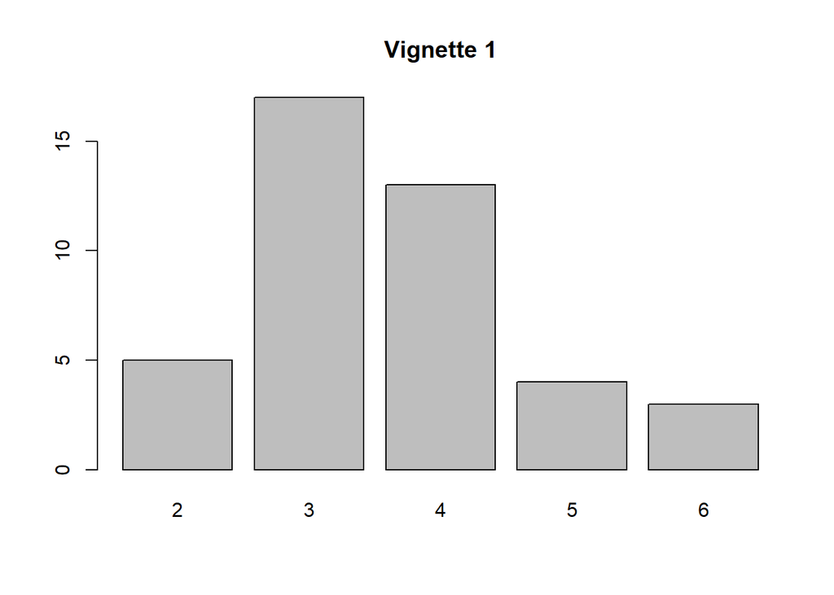

```r
data_vig1 <- data %>%
  dplyr::filter(vig == 1)

data_vig2 <- data %>%
  dplyr::filter(vig == 2)

data_vig3 <- data %>%
  dplyr::filter(vig == 3)

tab1 <- table(data_vig1$check_1)
tab2 <- table(data_vig2$check_1)
tab3 <- table(data_vig3$check_1)

barplot(tab1, main = "Vignette 1")
```

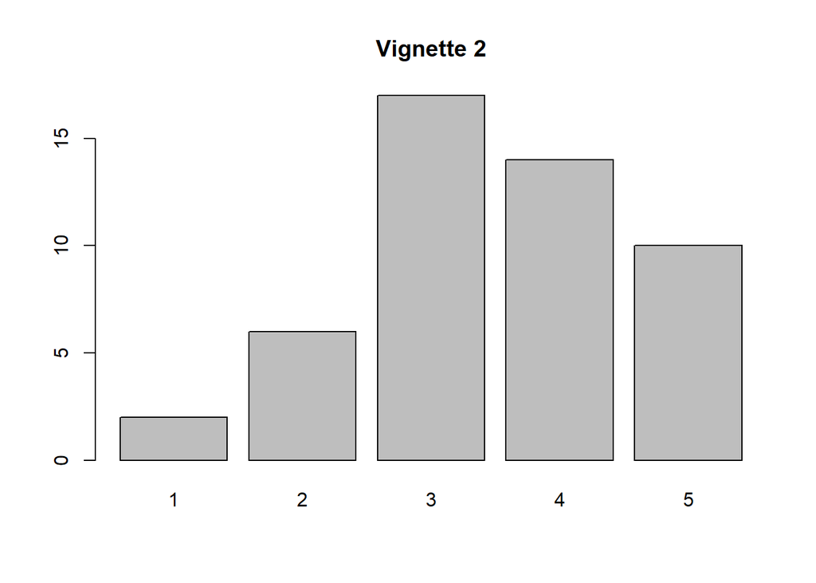

```r
barplot(tab2, main = "Vignette 2")
```

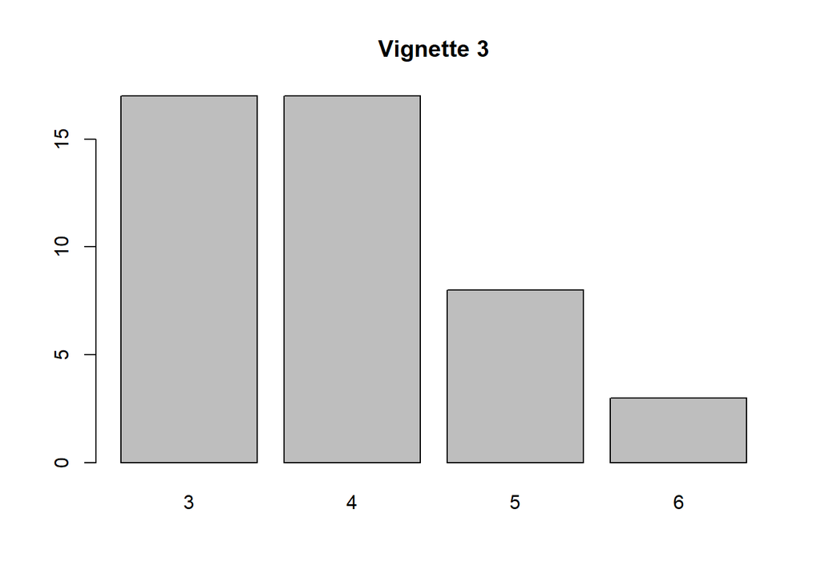

```r
barplot(tab3, main = "Vignette 3")
```

*Were the situations cause equally attributed?*

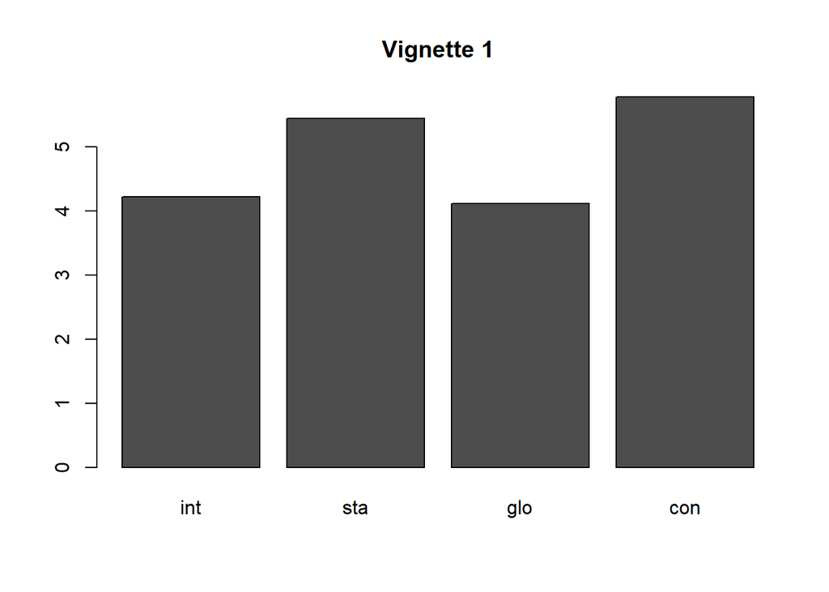

```r
tab1 <- data.frame(int = mean(data_vig1$int, na.rm = T),
                   sta = mean(data_vig1$sta, na.rm = T),
                   glo = mean(data_vig1$glo, na.rm = T),
                   con = mean(data_vig1$con, na.rm = T))

tab2 <- data.frame(int = mean(data_vig2$int, na.rm = T),
                   sta = mean(data_vig2$sta, na.rm = T),
                   glo = mean(data_vig2$glo, na.rm = T),
                   con = mean(data_vig2$con, na.rm = T))

tab3 <- data.frame(int = mean(data_vig3$int, na.rm = T),
                   sta = mean(data_vig3$sta, na.rm = T),
                   glo = mean(data_vig3$glo, na.rm = T),
                   con = mean(data_vig3$con, na.rm = T))

barplot(as.matrix(tab1), main = "Vignette 1")
```

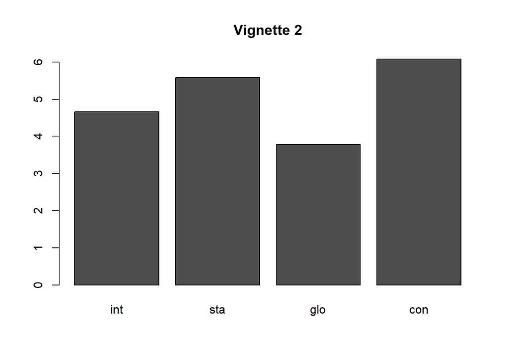

```r
barplot(as.matrix(tab2), main = "Vignette 2")
```

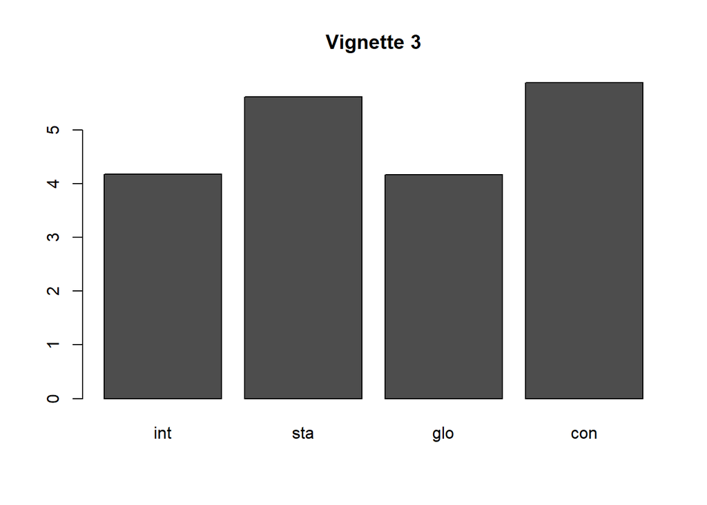

```r
barplot(as.matrix(tab3), main = "Vignette 3")
```

## Next Steps

- Nur mit Vignette 1 und 3 rechnen (?)
- Positive Emotionen anschauen
- Hätte es eine CFA sein sollen? Ich habe eine EFA gerechnet, weil ich mir ja Items ausgedacht habe und wissen wollte, welche davon die passenden sind.

## References

- Correlation Matrix

Breyer, B., & Bluemke, M. (2016). *Deutsche version der positive and negative affect schedule PANAS (GESIS panel)*.

Comrey, A. L. (1962). The minimum residual method of factor analysis. *Psychological Reports*, *11*(1), 15–18.

Georgiou, S. N., Christou, C., Stavrinides, P., & Panaoura, G. (2002). Teacher attributions of student failure and teacher behavior toward the failing student. *Psychology in the Schools*, *39*(5), 583–595.

Graham, S. (2020). An attributional theory of motivation. *Contemporary Educational Psychology*, *61*, 101861.

Richter, D., Kunter, M., Lüdtke, O., Klusmann, U., & Baumert, J. (2011). Soziale unterstützung beim berufseinstieg ins lehramt. *Zeitschrift für Erziehungswissenschaft*, *14*(1), 35–59.

*Soziale unterstützung bei der krankheitsbewältigung: Die berliner social support skalen (BSSS)soziale unterstützung bei der krankheitsbewältigung: Die berliner social support skalen (BSSS)* (2; pp. 73–82). (2003). Hogrefe Verlag.

Steinsmeier, J., Kammer, D., Pelster, A., & Niketta, R. (1985). Attributionsstil und bewertung als risikofaktoren der depressiven reaktion. *Bielefelder Arbeiten Zur Sozialpsychologie*.

Tabachnick, B. G., & Fidell, L. S. (2001). *Using multivariate statistics*. Allyn; Bacon. https://books.google.de/books?id=lVtqAAAAMAAJ

Tickell, R. M., & Klassen, R. M. (2024). Developing the teacher mentoring self-efficacy scale (TMSES) using the delphi method and exploratory factor analysis. *Teaching and Teacher Education*, *139*, 104452.

Weiner, B. (1985). An attributional theory of achievement motivation and emotion. *Psychological Review*, *92*(4), 548.